# Elections Result : Exploratory,Win and Voteshare prediction

Swarup Kumar

6/27/2019

```r
#Load data for 2017 UP assembly polls
incumup2017 <- read.xlsx("C:/BigData/BABI/Assignment4/LA2017_1.xlsx",sheetName = "Candidate",header = TRUE)
str(incumup2017)
```

```
## 'data.frame':    5306 obs. of  22 variables:
##  $ ST_CODE              : Factor w/ 1 level "S24": 1 1 1 1 1 1 1 1 1 1 ...
##  $ ST_NAME              : Factor w/ 1 level "Uttar Pradesh": 1 1 1 1 1 1 1 1 1 1 ...
##  $ MONTH                : num  3 3 3 3 3 3 3 3 3 3 ...
##  $ YEAR                 : num  2017 2017 2017 2017 2017 ...
##  $ DIST_NAME            : Factor w/ 75 levels "Agra","Aligarh",..: 63 63 63 63 63 63 63 63 63 63 ...
##  $ AC_NO                : num  1 1 1 1 1 1 1 1 1 1 ...
##  $ AC_NAME              : Factor w/ 405 levels "Agra Cantt. ",..: 62 62 62 62 62 62 62 62 62 62 ...
##  $ AC_TYPE              : Factor w/ 3 levels "GEN","SC","ST": 1 1 1 1 1 1 1 1 1 1 ...
##  $ CAND_NAME            : Factor w/ 4100 levels " GOPAL SHARMA",..: 2087 1679 1934 2912 2184 1428 307 1121 1057 1531 ...
##  $ CAND_SEX             : Factor w/ 4 levels "F","M","NULL",..: 2 2 2 2 3 2 2 2 2 2 ...
##  $ CAND_CATEGORY        : Factor w/ 4 levels "GEN","NULL","SC",..: 1 1 1 1 2 1 1 3 1 3 ...
##  $ CAND_AGE             : Factor w/ 62 levels "25","26","27",..: 29 31 28 25 62 13 14 15 8 11 ...
##  $ PARTYABBRE           : Factor w/ 304 levels "AABHAP","AACP",..: 122 71 97 123 192 60 232 123 123 123 ...
##  $ TOTALVALIDVOTESPOLLED: num  97035 71449 71019 4187 1576 ...
##  $ POSITION             : num  1 2 3 4 5 6 7 8 9 10 ...
##  $ Helper1              : Factor w/ 5245 levels " GOPAL SHARMA|Garhmukteshwar",..: 2417 1945 2249 3845 2581 1667 395 1318 1250 1788 ...
##  $ Criminal.Case        : num  0 0 0 0 0 0 2 0 0 0 ...
##  $ Education            : Factor w/ 13 levels "10th Pass","12th Pass",..: 13 8 10 2 6 1 2 3 1 6 ...
##  $ Total.Assets         : Factor w/ 3148 levels "FALSE","Nil",..: 64 2316 692 2544 1 2566 39 1356 29 1 ...
##  $ Liabilities          : Factor w/ 824 levels "FALSE","RsÂ 0",..: 435 402 11 315 1 2 121 2 2 1 ...
##  $ Party1               : Factor w/ 272 levels "Aadim Samaj Party",..: 104 83 85 105 92 63 229 105 105 92 ...
##  $ Won                  : num  1 0 0 0 0 0 0 0 0 0 ...
```

```r
#Load data for 2012 UP assembly polls
up2012 <- read.xlsx("C:/BigData/BABI/Assignment4/AE2012_8913.xlsx",sheetName = "Candidate",header = TRUE)
str(up2012)
```

```
## 'data.frame':    62621 obs. of  16 variables:
##  $ ST_CODE      : Factor w/ 1 level "S24": 1 1 1 1 1 1 1 1 1 1 ...
##  $ ST_NAME      : Factor w/ 1 level "Uttar Pradesh": 1 1 1 1 1 1 1 1 1 1 ...
##  $ MONTH        : num  1 1 1 1 1 1 1 1 1 1 ...
##  $ YEAR         : num  2012 2012 2012 2012 2012 ...
##  $ DIST_NAME    : Factor w/ 75 levels "Agra","Aligarh",..: 65 65 65 65 65 65 65 65 65 65 ...
##  $ AC_NO        : num  1 1 1 1 1 1 1 1 1 1 ...
##  $ AC_NAME      : Factor w/ 403 levels "Agra Cantt. ",..: 61 61 61 61 61 61 61 61 61 61 ...
##  $ AC_TYPE      : Factor w/ 2 levels "GEN","SC": 1 1 1 1 1 1 1 1 1 1 ...
##  $ CAND_NAME    : Factor w/ 5456 levels "(MO.) AKRAM CHOUHAN",..: 2339 2888 5092 122 1083 1078 433 2039 5395 20 ...
##  $ CAND_SEX     : Factor w/ 3 levels "F","M","O": 2 2 2 2 2 2 2 2 2 2 ...
##  $ CAND_CATEGORY: Factor w/ 3 levels "GEN","SC","ST": 1 1 1 1 2 1 1 1 2 1 ...
##  $ CAND_AGE     : num  50 47 34 29 39 39 31 35 28 35 ...
##  $ PARTYABBRE   : Factor w/ 223 levels "A S P","Aa S P",..: 62 81 205 40 67 82 124 192 5 136 ...
##  $ TOTVOTPOLL   : num  70274 69760 47366 23623 2251 ...
##  $ POSITION     : num  1 2 3 4 5 6 7 8 9 10 ...
##  $ Won          : num  1 0 0 0 0 0 0 0 0 0 ...
```

```r
#Pick only Constituency name, Party abbrievation and Won variable from both data frames
idf1 <- data.frame(incumup2017$AC_NO,incumup2017$AC_NAME,incumup2017$PARTYABBRE,incumup2017$Won)
idf2 <- data.frame(up2012$AC_NO,up2012$AC_NAME,up2012$PARTYABBRE,up2012$Won)

#Filter bpth data frames where they Won in 2012,2017
idf11 <- idf1 %>% filter(incumup2017.Won==1)
idf21 <- idf2 %>% filter(up2012.Won==1)
#Merge the dataframe based on Constituency name
merdf <- merge(idf11,idf21,by.x = "incumup2017.AC_NO",by.y = "up2012.AC_NO")
levenScore <- levenshteinSim(tolower(as.character(merdf$incumup2017.PARTYABBRE)),tolower(as.character(merdf$up2012.PARTYABBRE)))

incumFn <- function(x)
{
  incumbVec <- c()
for(i in 1:length(x))
{

  if(x[i] == 1)
  {
    incumbElem <- merdf$incumup2017.Won[i] - merdf$up2012.Won[i]

  }
  else
  {
    incumbElem <- -1
  }
 incumbVec <- c(incumbVec,incumbElem)
}
  return(incumbVec)
}

incumbDf <- incumFn(levenScore)

merdf <- cbind(merdf,incumbDf)
str(merdf)
```

```
## 'data.frame':    403 obs. of  7 variables:
##  $ incumup2017.AC_NO     : num  1 2 3 4 5 6 7 8 9 10 ...
##  $ incumup2017.AC_NAME   : Factor w/ 405 levels "Agra Cantt. ",..: 62 284 341 340 112 325 134 185 388 361 ...
##  $ incumup2017.PARTYABBRE: Factor w/ 304 levels "AABHAP","AACP",..: 122 71 283 122 71 71 71 283 71 71 ...
##  $ incumup2017.Won       : num  1 1 1 1 1 1 1 1 1 1 ...
##  $ up2012.AC_NAME        : Factor w/ 403 levels "Agra Cantt. ",..: 61 284 340 339 112 324 134 185 387 360 ...
##  $ up2012.PARTYABBRE     : Factor w/ 223 levels "A S P","Aa S P",..: 62 62 40 62 205 62 81 40 40 81 ...
##  $ up2012.Won            : num  1 1 1 1 1 1 1 1 1 1 ...
```

#Plot the barplot showing how much of Pro/Anti Incumbency against the political parties

```r
ggplot(aes(y =merdf$incumbDf , x = merdf$incumup2017.PARTYABBRE), data = merdf) + geom_boxplot()
```

[figure not shown]

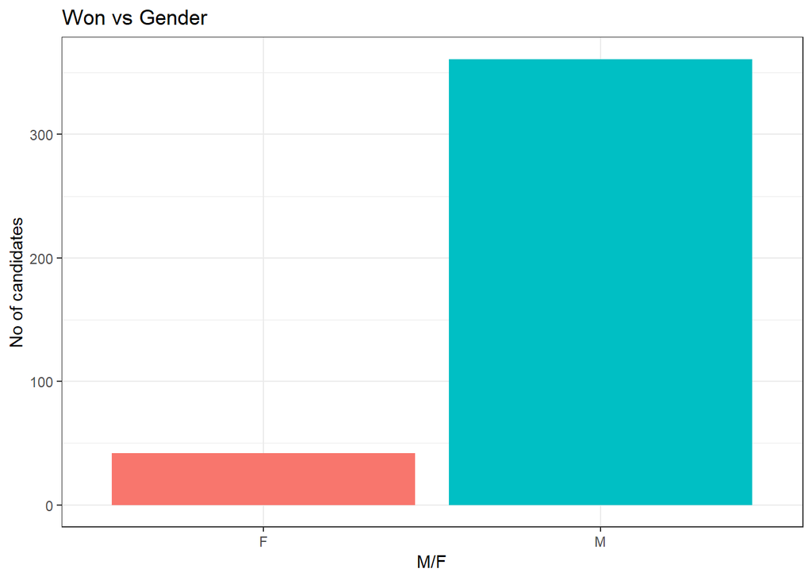

```r
#Exploratory model : factors contributing to Win followed by Prediction model
#Remove ST_CODE,ST_NAME,MONTH,YEAR,AC_NO,AC_TYPE,Helper1,Party1 for further analysis as these are not of importance

incumup2017Filtered1 <- incumup2017[,c(-1,-2,-3,-4,-8,-16,-21)]

#Formating Total.Assets,Liabilities,Age
#Format Rs in the assets, Liabilities column; During the vlookup ~ Rs 3 crore+ kind of automatically removed

#str(incumup2017Filtered1)
#Substitue FALSE,Nil with 0 and Rs & , with blank
incumup2017Filtered1[,14] <- gsub("FALSE",0,incumup2017Filtered1[,14])
incumup2017Filtered1[,14] <- gsub("Nil",0,incumup2017Filtered1[,14])
incumup2017Filtered1[,14] <- gsub("Rs","",incumup2017Filtered1[,14])
incumup2017Filtered1[,14] <- gsub(",","",incumup2017Filtered1[,14])


#Convert Total.Assets to numeric type
incumup2017Filtered1[,14] <- parse_number(incumup2017Filtered1[,14])

#Format Rs in the assets, Liabilities column; During the vlookup ~ Rs 3 crore+ kind of automatically removed
#Substitue FALSE,Nil with 0 and Rs & , with blank
incumup2017Filtered1[,13] <- gsub("FALSE",0,incumup2017Filtered1[,13])
incumup2017Filtered1[,13] <- gsub("Nil",0,incumup2017Filtered1[,13])
incumup2017Filtered1[,13] <- gsub("Rs","",incumup2017Filtered1[,13])
incumup2017Filtered1[,13] <- gsub(",","",incumup2017Filtered1[,13])
#Convert Liabilities to numeric type
incumup2017Filtered1[,13] <- parse_number(incumup2017Filtered1[,13])

#Age as Numeric variables
#Replace 0 for all NULL values i.e. for NOTA option
incumup2017Filtered1[,7] <- gsub("NULL",0,incumup2017Filtered1[,7])
#Convert Liabilities to numeric type
incumup2017Filtered1[,7] <- parse_number(incumup2017Filtered1[,7])

#Education,Sex,CAND_CATEGORY are categorical variables ; convert them into dummy variables

#Transform for Education Categories as Under Graduate -> 12th and below pass, Graduate,Post Graduate,Doctorate
#All not given data will be marked Ignored because if we remove them, then analysis data will be reduced
incumup2017Filtered1[,12] <- as.factor(gsub("FALSE","Ignored",incumup2017Filtered1[,12]))
incumup2017Filtered1[,12] <- as.factor(gsub("Others","Ignored",incumup2017Filtered1[,12]))
incumup2017Filtered1[,12] <- as.factor(gsub("Not Given","Ignored",incumup2017Filtered1[,12]))

incumup2017Filtered1[,12] <- as.factor(gsub("10th Pass","Under Graduate",incumup2017Filtered1[,12]))
incumup2017Filtered1[,12] <- as.factor(gsub("8th Pass","Under Graduate",incumup2017Filtered1[,12]))
incumup2017Filtered1[,12] <- as.factor(gsub("5th Pass","Under Graduate",incumup2017Filtered1[,12]))
incumup2017Filtered1[,12] <- as.factor(gsub("12th Pass","Under Graduate",incumup2017Filtered1[,12]))

#Replace NULL with NA to ignore NOTA option for CAND_SEX variable
incumup2017Filtered1[,5] <- as.factor(gsub("NULL",NA,incumup2017Filtered1[,5]))
incumup2017Filtered1[,5] <- as.factor(gsub("O",NA,incumup2017Filtered1[,5]))

#Remove all NA rows for exploratory analysis, exclude NOTA and reassign it to new variable for exploratory analysis
incumup2017Filtered <- na.omit(incumup2017Filtered1)
#Create netasset variable and append that to main dataframe
netasset <- incumup2017Filtered$Total.Assets - incumup2017Filtered$Liabilities
incumup2017Filtered <- cbind(incumup2017Filtered,netasset)

#Filter for only top political parties
partyabbre <- filter(incumup2017Filtered,PARTYABBRE %in% c("BJP","INC","SP","BSP","RLD","ADAL"))
#Make Age categories only for exploratory analysis
CutAge <- cut(partyabbre$CAND_AGE,breaks=c(0,25,35,50,65,Inf),labels=c("25","25to35","35to50","50to65",">65"))
#Make netasset categories only for exploratory analysis
CutnetAsset <- cut(partyabbre$netasset,breaks=c(-Inf,0,1000000,2500000,5000000,10000000,Inf),labels=c("Negative","Upto10L","10Lto25L","25Lto50L","50Lto1CR",">1CR"))

#Exploraotry Analysis based on Wins (Won variable of the dataset where Won==1)

wonfilter <- filter(incumup2017Filtered,Won==1)
#Make Age categories only for exploratory analysis
CutAgeW <- cut(wonfilter$CAND_AGE,breaks=c(0,25,35,50,65,Inf),labels=c("25","25to35","35to50","50to65",">65"))
#Make netasset categories only for exploratory analysis
CutnetAssetW <- cut(wonfilter$netasset,breaks=c(-Inf,0,1000000,2500000,5000000,10000000,Inf),labels=c("Negative","Upto10L","10Lto25L","25Lto50L","50Lto1CR",">1CR"))
#How many Male / Female candidates Won
wonfilter %>% group_by(CAND_SEX) %>% summarise(win=sum(Won)) %>%
  ggplot(aes(x = CAND_SEX, y = win, fill = CAND_SEX)) +
    geom_bar(stat = "identity",show.legend = FALSE) +
    theme_bw() +
    labs(
        x = "M/F",
        y = "No of candidates",
        title = paste(
            "Won vs Gender "
        )
    )
```

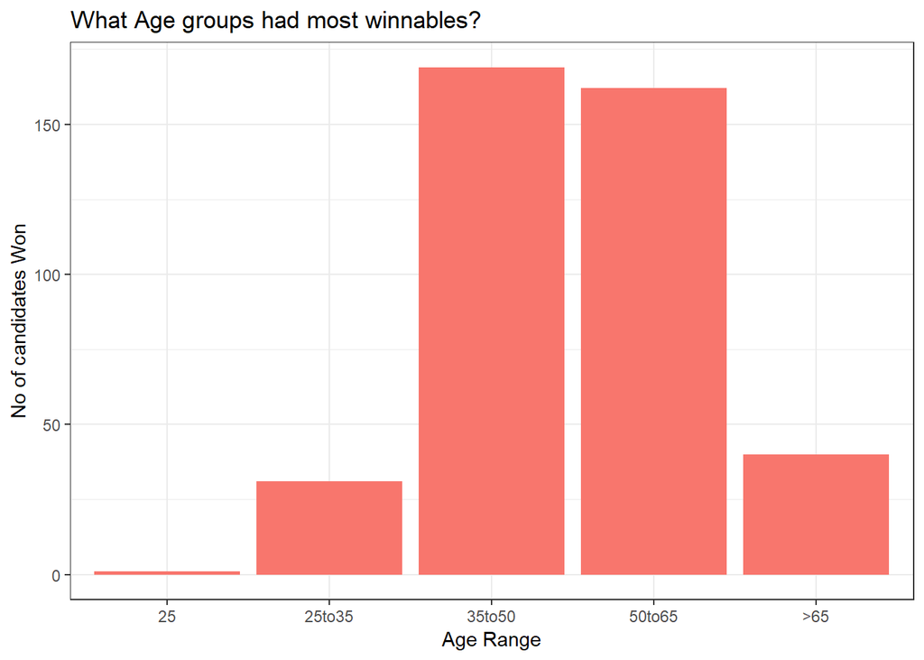

```r
#What Age groups had most winnables?
  ggplot(data=wonfilter)+
   geom_bar(aes(x=CutAgeW,fill=as.factor(Won)),show.legend = FALSE)+
   ggtitle(label="Age group of Winnables  ")+
   theme_bw()+labs(
         x = "Age Range",
         y = "No of candidates Won",
         title = paste(
             "What Age groups had most winnables? "
         ))
```

**More number of candidates who won were in 35 to 65 years and very few candidates won below 30 years of age**

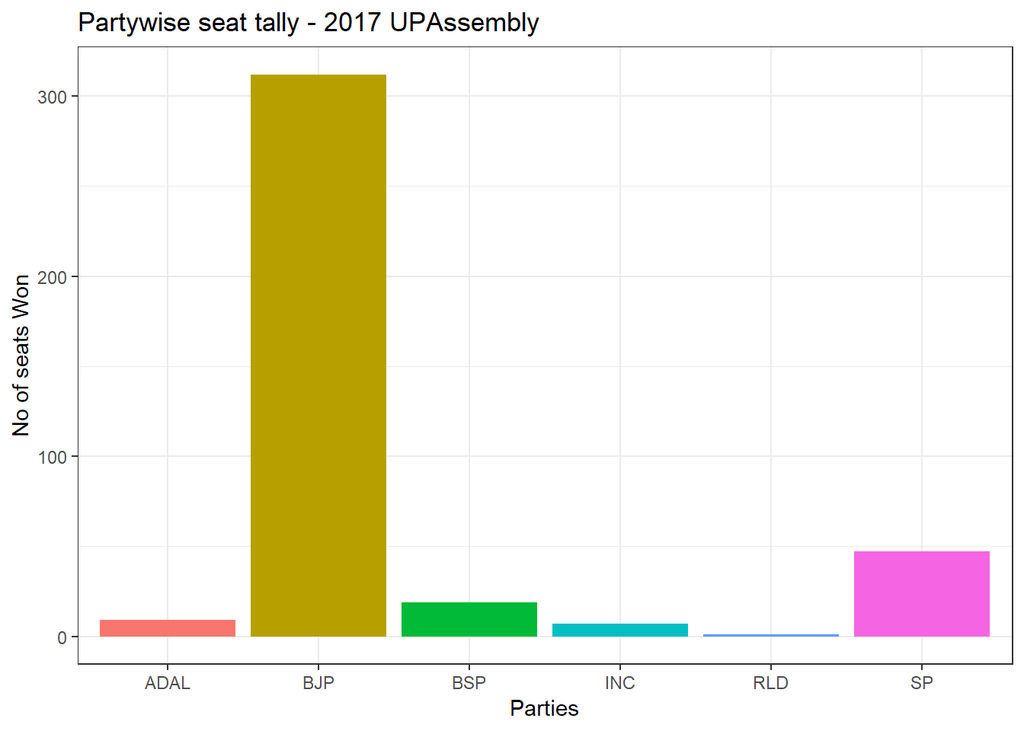

```r
 #+geom_text(aes(label=CutnetAssetW),vjust=0.2,colour="black",size=5)
#Partywise seat won
partyabbre %>% group_by(PARTYABBRE) %>% summarise(sum_votes=sum(Won)) %>%
  ggplot(aes(x = PARTYABBRE, y = sum_votes, fill = PARTYABBRE)) +
    geom_bar(stat = "identity",show.legend = FALSE)+
    theme_bw() +
    labs(
        x = "Parties",
        y = "No of seats Won",
        title = paste(
            "Partywise seat tally - 2017 UPAssembly"
        )
    )
```

**BJP won the elections of 2017 with more than 2/3 majority of the available 403 assembly**

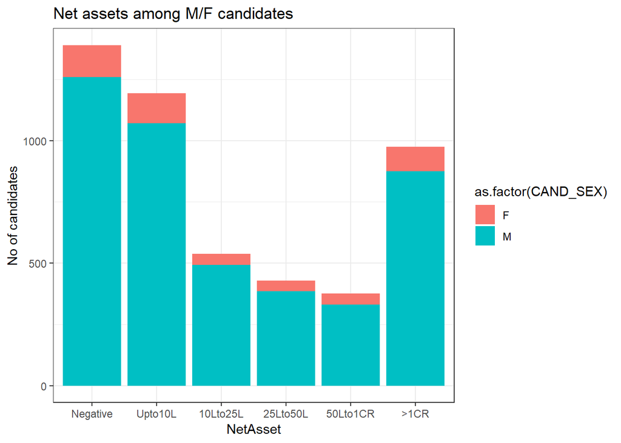

```r
CutnetAssetF <- cut(incumup2017Filtered$netasset,breaks=c(-Inf,0,1000000,2500000,5000000,10000000,Inf),labels=c("Negative","Upto10L","10Lto25L","25Lto50L","50Lto1CR",">1CR"))
#NetAsset among M/F
ggplot(data=incumup2017Filtered)+geom_bar(aes(x=CutnetAssetF,fill=as.factor(CAND_SEX)))+theme_bw()+labs(
        x = "NetAsset",
        y = "No of candidates",
        title = paste(
            "Net assets among M/F candidates"
        ))
```

**More Crorepatis and also people with Liabilities were Men as compared to Women**

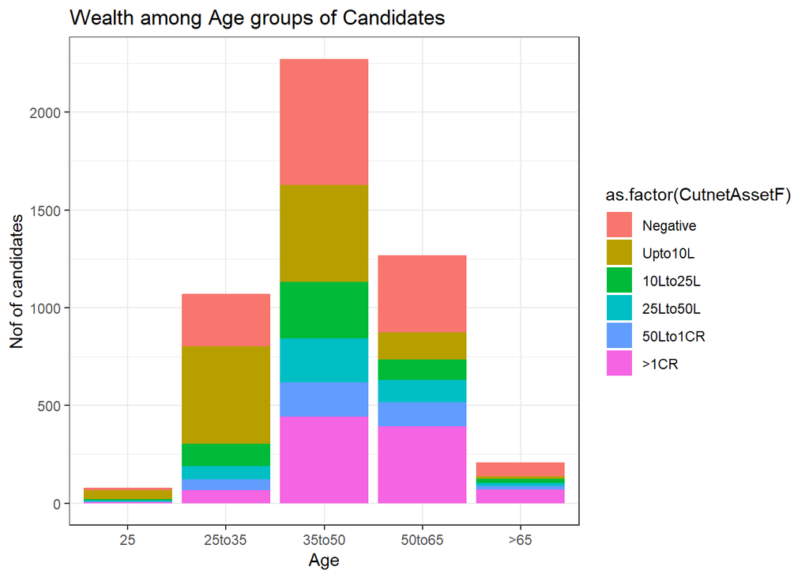

```r
#Netasset among Age groups
CutAgeF <- cut(incumup2017Filtered$CAND_AGE,breaks=c(0,25,35,50,65,Inf),labels=c("25","25to35","35to50","50to65",">65"))
ggplot(data=incumup2017Filtered)+geom_bar(aes(x=CutAgeF,fill=as.factor(CutnetAssetF)))+theme_bw()+labs(
        x = "Age",
        y = "Nof of candidates",
        title = paste(
            "Wealth among Age groups of Candidates"
        ))
```

**More Crorepatis were in the age range 35to50 years**

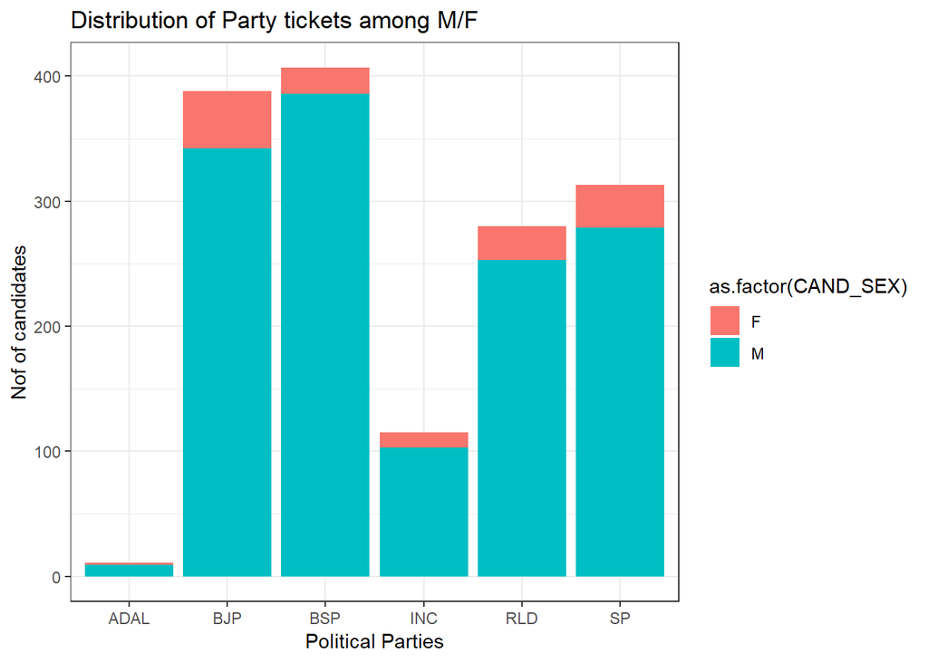

```r
#Partywise (among top 6) M/F
ggplot(data=partyabbre)+geom_bar(aes(x=PARTYABBRE,fill=as.factor(CAND_SEX)))+theme_bw()+labs(
        x = "Political Parties",
        y = "Nof of candidates",
        title = paste(
            "Distribution of Party tickets among M/F"
        ))
```

**BJP gave more tickets to Women followed by SP. However majority candidates from all parties were Men**

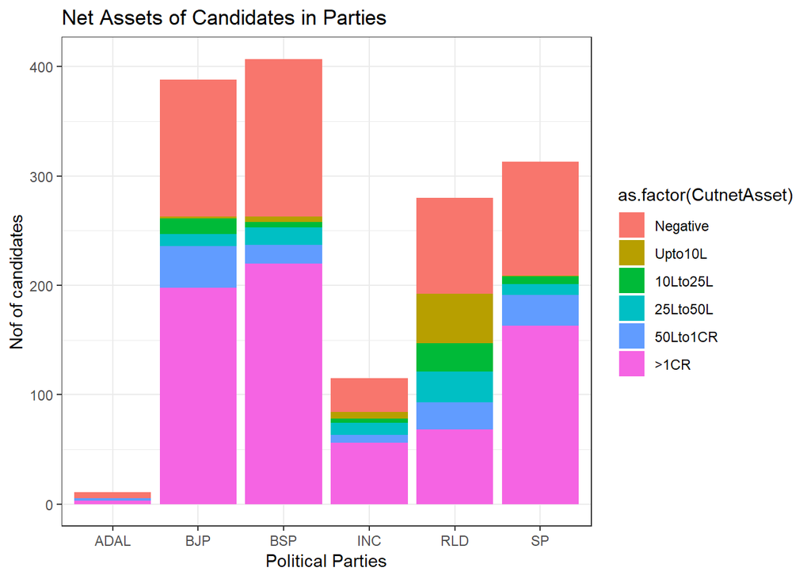

```r
#Partywise netasset details
ggplot(data=partyabbre)+geom_bar(aes(x=PARTYABBRE,fill=as.factor(CutnetAsset)))+theme_bw()+labs(
        x = "Political Parties",
        y = "Nof of candidates",
        title = paste(
            "Net Assets of Candidates in Parties"
        ))
```

**BSP had the most crorepatis followed by BJP and SP. BSP and BJP had the most candidates who had -ve Liabilities**

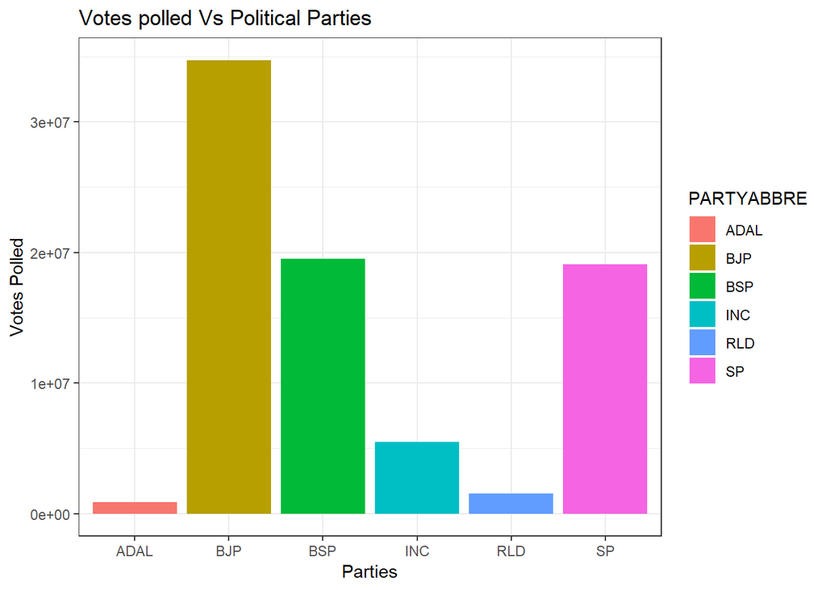

```r
#Partywise Votes garnered
partyabbre %>% group_by(PARTYABBRE) %>% summarise(sum_votes=sum(TOTALVALIDVOTESPOLLED)) %>%
  ggplot(aes(x = PARTYABBRE, y = sum_votes, fill = PARTYABBRE)) +
    geom_bar(stat = "identity") +
    theme_bw() +
    labs(
        x = "Parties",
        y = "Votes Polled",
        title = paste(
            "Votes polled Vs Political Parties "
        )
    )
```

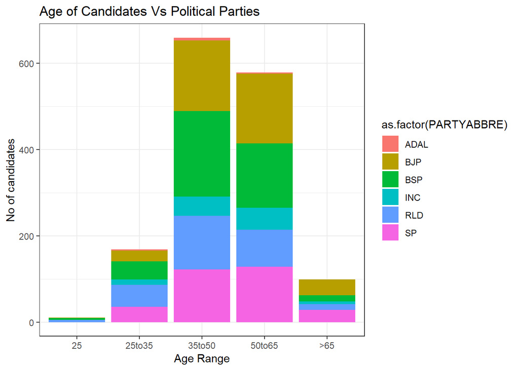

```r
#Partywise ticket distribution Vs Age
ggplot(data=partyabbre)+geom_bar(aes(x=CutAge,fill=as.factor(PARTYABBRE)))+theme_bw()+labs(
        x = "Age Range",
        y = "No of candidates",
        title = paste(
            "Age of Candidates Vs Political Parties "
        ))
```

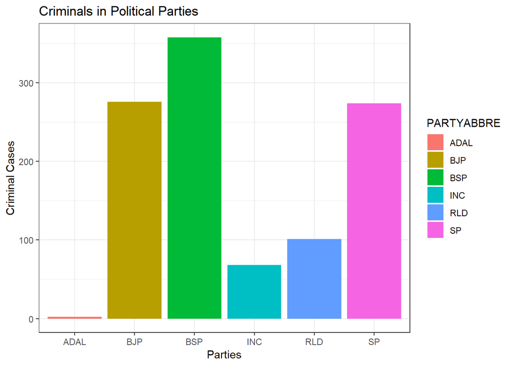

```r
#Partywise Criminal cases of Candidates
partyabbre %>% group_by(PARTYABBRE) %>% summarise(sum_votes=sum(Criminal.Case)) %>%
  ggplot(aes(x = PARTYABBRE, y = sum_votes, fill = PARTYABBRE)) +
    geom_bar(stat = "identity") +
    theme_bw() +
    labs(
        x = "Parties",
        y = "Criminal Cases",
        title = paste(
            "Criminals in Political Parties "
        )
    )
```

**BSP had the maximum candidates with Criminal records. BJP and SP had the same number of criminal candidates**

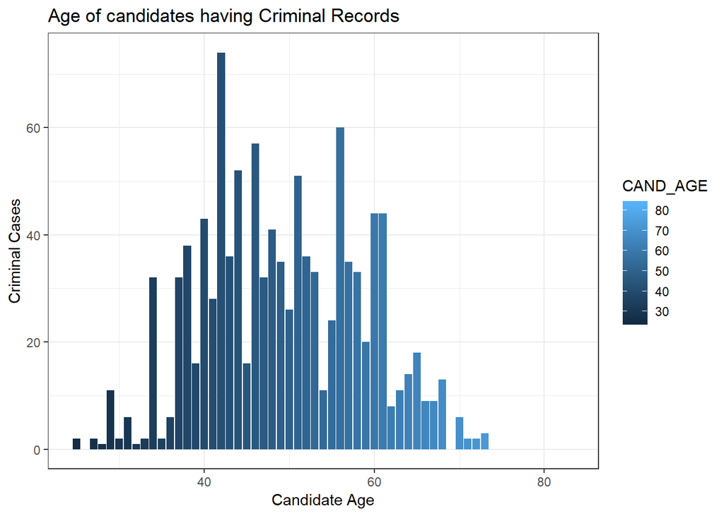

```r
#Partywise Criminal cases Vs Age
partyabbre %>% group_by(CAND_AGE) %>% summarise(sum_votes=sum(Criminal.Case)) %>%
  ggplot(aes(x = CAND_AGE, y = sum_votes, fill = CAND_AGE)) +
    geom_bar(stat = "identity") +
    theme_bw() +
    labs(
        x = "Candidate Age",
        y = "Criminal Cases",
        title = paste(
            "Age of candidates having Criminal Records"
        )
    )
```

**Candidates in the range of 40 to 60 years had the most criminal records**

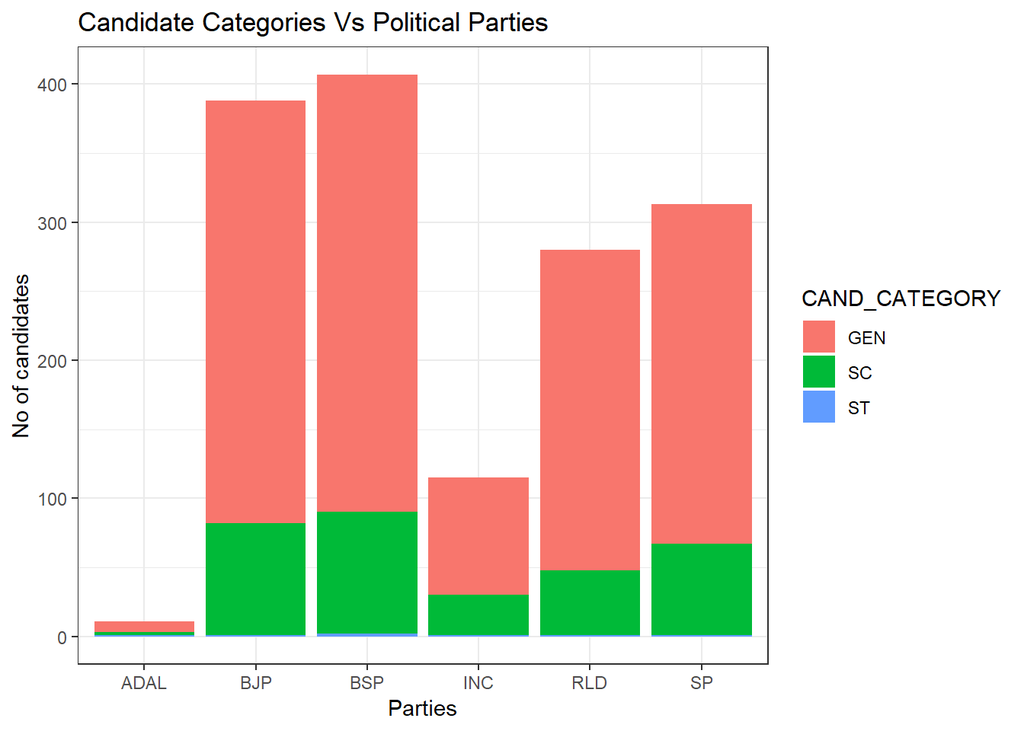

```r
#Partywise Candidate categories
ggplot(data=partyabbre)+geom_bar(aes(x=PARTYABBRE,fill=CAND_CATEGORY))+theme_bw()+labs(
        x = "Parties",
        y = "No of candidates",
        title = paste(
            "Candidate Categories Vs Political Parties"
        ))
```

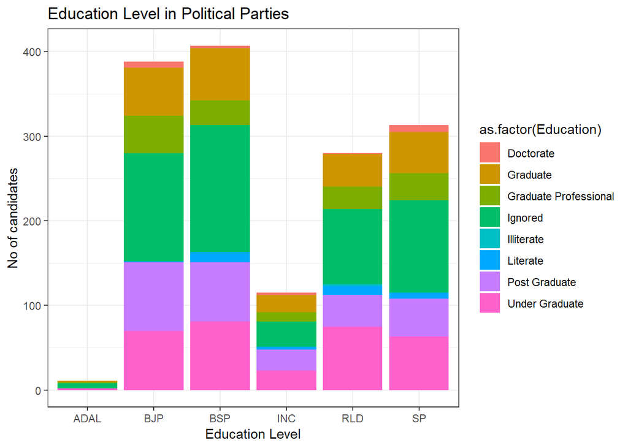

```r
#Education level in Parties
ggplot(data=partyabbre)+geom_bar(aes(x=PARTYABBRE,fill=as.factor(Education)))+theme_bw()+labs(
        x = "Education Level",
        y = "No of candidates",
        title = paste(
            "Education Level in Political Parties "
        ))
```

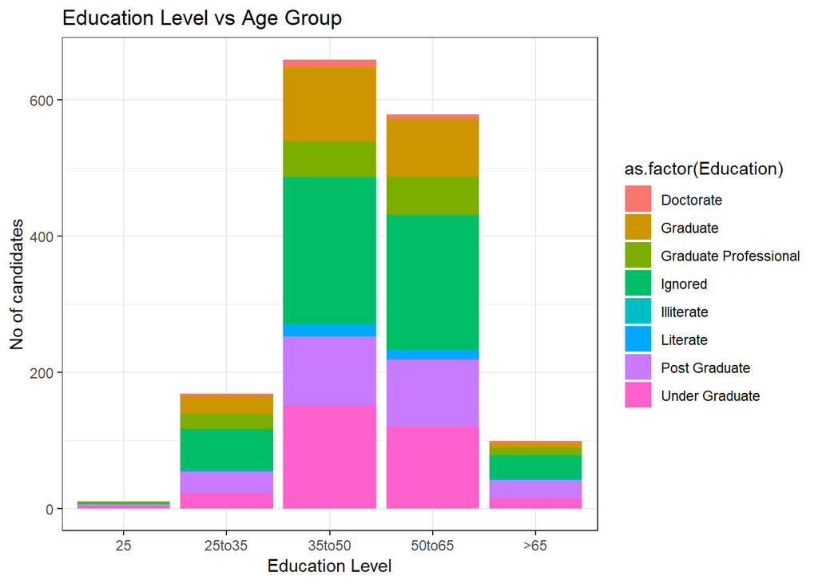

```r
#Education level among Age Groups
ggplot(data=partyabbre)+geom_bar(aes(x=CutAge,fill=as.factor(Education)))+theme_bw()+labs(
        x = "Education Level",
        y = "No of candidates",
        title = paste(
            "Education Level vs Age Group "
        ))
```

**Maximum number of Graduate (and above) were in the range of 35 to 65 years**

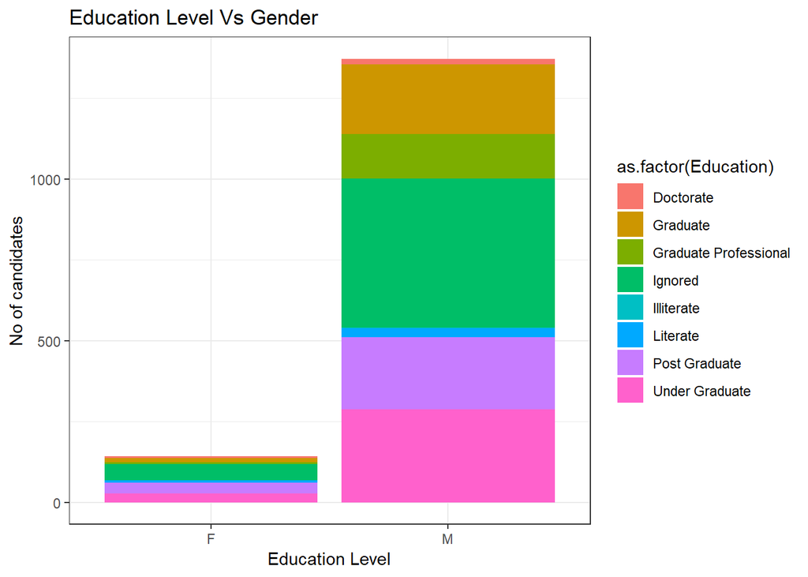

```r
#Education level among M/F
ggplot(data=partyabbre)+geom_bar(aes(x=CAND_SEX,fill=as.factor(Education)))+theme_bw()+labs(
        x = "Education Level",
        y = "No of candidates",
        title = paste(
            "Education Level Vs Gender"
        ))
```

```r
# #Check for outliers using Boxplot for numeric variables
# boxplot(incumup2017Filtered$CAND_AGE~incumup2017Filtered$POSITION)
# boxplot(incumup2017Filtered$Total.Assets~incumup2017Filtered$POSITION)
# boxplot(partyabbre$netasset~partyabbre$POSITION)

# #Overall Education levels of all Candidates across party lines
# plot(incumup2017Filtered$Education)
# #Category of Candidates across party lines
# #plot(incumup2017Filtered$CAND_CATEGORY)
# plot(incumup2017Filtered$CAND_SEX)

#Data transformation to proceed for Prediction Model
#Create dummy variable for Categorical Variables Gender,Category,Education
dmy<- dummy_cols(incumup2017Filtered, select_columns = c("CAND_SEX","CAND_CATEGORY","Education"))
#Check the structure of dataset after applying dummy variables
str(dmy)
```

```
## 'data.frame':    4898 obs. of  29 variables:
##  $ DIST_NAME                      : Factor w/ 75 levels "Agra","Aligarh",..: 63 63 63 63 63 63 63 63 63 63 ...
##  $ AC_NO                          : num  1 1 1 1 1 1 1 1 1 1 ...
##  $ AC_NAME                        : Factor w/ 405 levels "Agra Cantt. ",..: 62 62 62 62 62 62 62 62 62 62 ...
##  $ CAND_NAME                      : Factor w/ 4100 levels " GOPAL SHARMA",..: 2087 1679 1934 2912 1428 307 1121 1057 1531 1400 ...
##  $ CAND_SEX                       : Factor w/ 2 levels "F","M": 2 2 2 2 2 2 2 2 2 2 ...
##  $ CAND_CATEGORY                  : Factor w/ 4 levels "GEN","NULL","SC",..: 1 1 1 1 1 1 3 1 3 1 ...
##  $ CAND_AGE                       : num  53 55 52 49 37 38 39 32 35 45 ...
##  $ PARTYABBRE                     : Factor w/ 304 levels "AABHAP","AACP",..: 122 71 97 123 60 232 123 123 123 123 ...
##  $ TOTALVALIDVOTESPOLLED          : num  97035 71449 71019 4187 1255 ...
##  $ POSITION                       : num  1 2 3 4 6 7 8 9 10 11 ...
##  $ Criminal.Case                  : num  0 0 0 0 0 2 0 0 0 0 ...
##  $ Education                      : Factor w/ 8 levels "Doctorate","Graduate",..: 7 3 6 8 8 8 8 8 4 4 ...
##  $ Total.Assets                   : num  1.08e+07 5.57e+07 1.40e+08 6.59e+07 6.83e+05 ...
##  $ Liabilities                    : num  398000 2985082 10214938 286731 0 ...
##  $ Won                            : num  1 0 0 0 0 0 0 0 0 0 ...
##  $ netasset                       : num  1.04e+07 5.27e+07 1.30e+08 6.56e+07 6.83e+05 ...
##  $ CAND_SEX_M                     : int  1 1 1 1 1 1 1 1 1 1 ...
##  $ CAND_SEX_F                     : int  0 0 0 0 0 0 0 0 0 0 ...
##  $ CAND_CATEGORY_GEN              : int  1 1 1 1 1 1 0 1 0 1 ...
##  $ CAND_CATEGORY_SC               : int  0 0 0 0 0 0 1 0 1 0 ...
##  $ CAND_CATEGORY_ST               : int  0 0 0 0 0 0 0 0 0 0 ...
##  $ Education_Post Graduate        : int  1 0 0 0 0 0 0 0 0 0 ...
##  $ Education_Graduate Professional: int  0 1 0 0 0 0 0 0 0 0 ...
##  $ Education_Literate             : int  0 0 1 0 0 0 0 0 0 0 ...
##  $ Education_Under Graduate       : int  0 0 0 1 1 1 1 1 0 0 ...
##  $ Education_Ignored              : int  0 0 0 0 0 0 0 0 1 1 ...
##  $ Education_Graduate             : int  0 0 0 0 0 0 0 0 0 0 ...
##  $ Education_Illiterate           : int  0 0 0 0 0 0 0 0 0 0 ...
##  $ Education_Doctorate            : int  0 0 0 0 0 0 0 0 0 0 ...
```

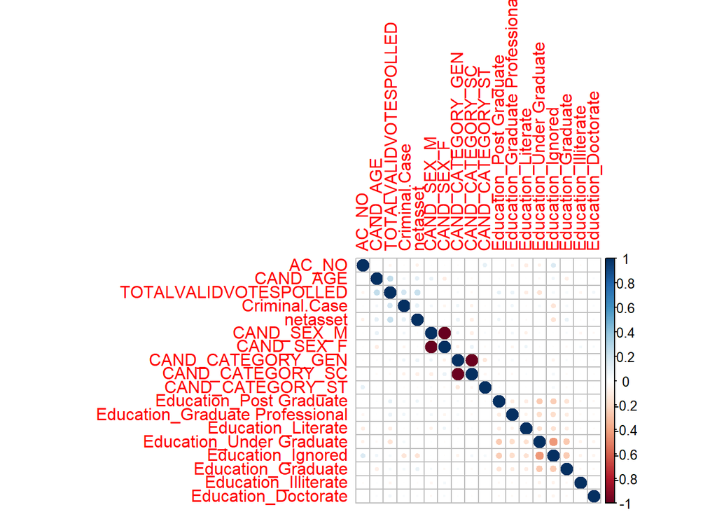

```r
#Remove the factor variables except target variable, Won
trsfm<- dmy[,c(-4,-5,-6,-10,-12,-13,-14)]
#Convert Won variable to factorial or else models won't run
trsfm[,8] <- as.factor(trsfm[,8])

#Running corrplot on all numeric variables
corrplot(cor(trsfm[,c(-1,-3,-5,-8)]), method = "circle")
```

**NetAssets,Age and Criminal cases had more correlation to Votes polled**

**Under graduate and total votes polled are somewhat negatively correlated**

```r
# Check for data consistency using KMO
KMO(trsfm[,c(-1,-3,-5,-8)])
```

```
## matrix is not invertible, image not found
```

```
## Kaiser-Meyer-Olkin factor adequacy
## Call: KMO(r = trsfm[, c(-1, -3, -5, -8)])
## Overall MSA =  0.5
## MSA for each item =
##                           AC_NO                        CAND_AGE
##                             0.5                             0.5
##           TOTALVALIDVOTESPOLLED                   Criminal.Case
##                             0.5                             0.5
##                        netasset                      CAND_SEX_M
##                             0.5                             0.5
##                      CAND_SEX_F               CAND_CATEGORY_GEN
##                             0.5                             0.5
##                CAND_CATEGORY_SC                CAND_CATEGORY_ST
##                             0.5                             0.5
##         Education_Post Graduate Education_Graduate Professional
##                             0.5                             0.5
##              Education_Literate        Education_Under Graduate
##                             0.5                             0.5
##               Education_Ignored              Education_Graduate
##                             0.5                             0.5
##            Education_Illiterate             Education_Doctorate
##                             0.5                             0.5
```

```r
#Won is the target variable or to be predicted, Party with Position 1 is 1 or else 0

#Model to be Won~distname,acname,candname,age,sex,partyabbr,criminalcase,education,assets,liabilities,Totalvalidvotespolled - Position
```

# C45 Technique

```r
#Creating data partition for train,test and Holdout
set.seed(12345)

#Split the dataset into train, test and holdout (65%,15%,20%)

sampleR <- sample.int(n = nrow(trsfm), size = floor(.65*nrow(trsfm)), replace = F)
sampleR1 <- sample.int(n = nrow(trsfm), size = floor(.15*nrow(trsfm)), replace = F)
sampleR2 <- sample.int(n = nrow(trsfm), size = floor(0.2*nrow(trsfm)), replace = F)

trainC45 <- trsfm[sampleR, ]
testC45  <- trsfm[sampleR1,]
holdoutC45 <- trsfm[sampleR2,]

#Fit the model
fitTrainRWeka <- J48(Won~., data=trainC45)

# summarize the fit
summary(fitTrainRWeka)
```

```
##
## === Summary ===
##
## Correctly Classified Instances        3094               97.2039 %
## Incorrectly Classified Instances        89                2.7961 %
## Kappa statistic                          0.7952
## Mean absolute error                      0.0434
## Root mean squared error                  0.1474
## Relative absolute error                 30.2932 %
## Root relative squared error             55.0823 %
## Total Number of Instances             3183
##
## === Confusion Matrix ===
##
##     a    b   <-- classified as
##  2904   32 |    a = 0
##    57  190 |    b = 1
```

```r
# make predictions

predictionsTestRWeka <- predict(fitTrainRWeka, testC45)
predictionsholdRWeka <- predict(fitTrainRWeka, holdoutC45)


caret::confusionMatrix(predictionsTestRWeka,testC45$Won,positive="1",mode="everything")
```

```
## Confusion Matrix and Statistics
##
##           Reference
## Prediction   0   1
##          0 672  17
##          1   2  43
##
##                Accuracy : 0.9741
##                  95% CI : (0.9599, 0.9843)
##     No Information Rate : 0.9183
##     P-Value [Acc > NIR] : 1.848e-10
##
##                   Kappa : 0.8054
##
##  Mcnemar's Test P-Value : 0.001319
##
##             Sensitivity : 0.71667
##             Specificity : 0.99703
##          Pos Pred Value : 0.95556
##          Neg Pred Value : 0.97533
##               Precision : 0.95556
##                  Recall : 0.71667
##                      F1 : 0.81905
##              Prevalence : 0.08174
##          Detection Rate : 0.05858
##    Detection Prevalence : 0.06131
##       Balanced Accuracy : 0.85685
##
##        'Positive' Class : 1
##
```

```r
caret::confusionMatrix(predictionsholdRWeka,holdoutC45$Won,positive="1",mode="everything")
```

```
## Confusion Matrix and Statistics
##
##           Reference
## Prediction   0   1
##          0 896  30
##          1   3  50
##
##                Accuracy : 0.9663
##                  95% CI : (0.953, 0.9767)
##     No Information Rate : 0.9183
##     P-Value [Acc > NIR] : 6.504e-10
##
##                   Kappa : 0.7346
##
##  Mcnemar's Test P-Value : 6.011e-06
##
##             Sensitivity : 0.62500
##             Specificity : 0.99666
##          Pos Pred Value : 0.94340
##          Neg Pred Value : 0.96760
##               Precision : 0.94340
##                  Recall : 0.62500
##                      F1 : 0.75188
##              Prevalence : 0.08172
##          Detection Rate : 0.05107
##    Detection Prevalence : 0.05414
##       Balanced Accuracy : 0.81083
##
##        'Positive' Class : 1
##
```

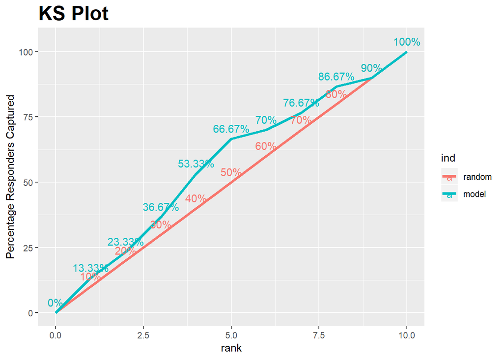

```r
ks_plot(testC45$Won,predictionsTestRWeka)
```

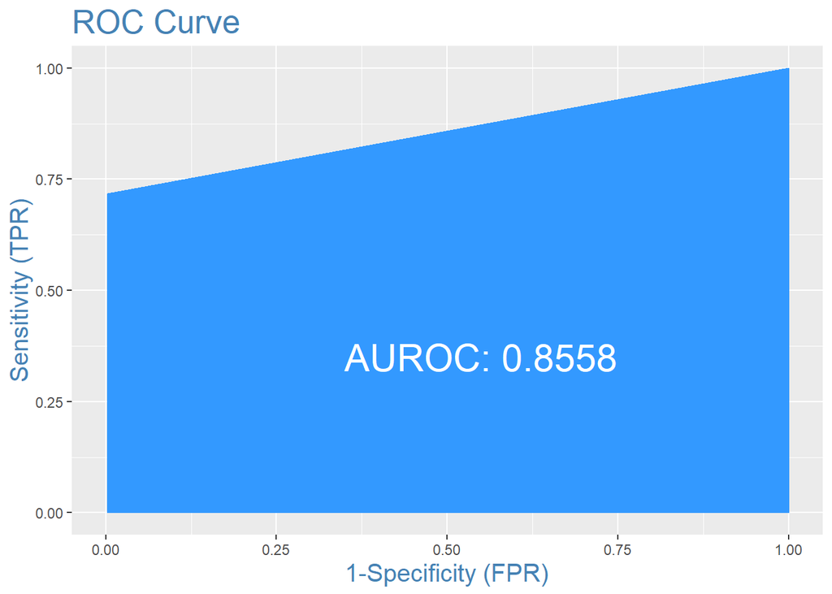

```r
InformationValue::plotROC(testC45$Won,c(as.numeric(predictionsTestRWeka)))
```

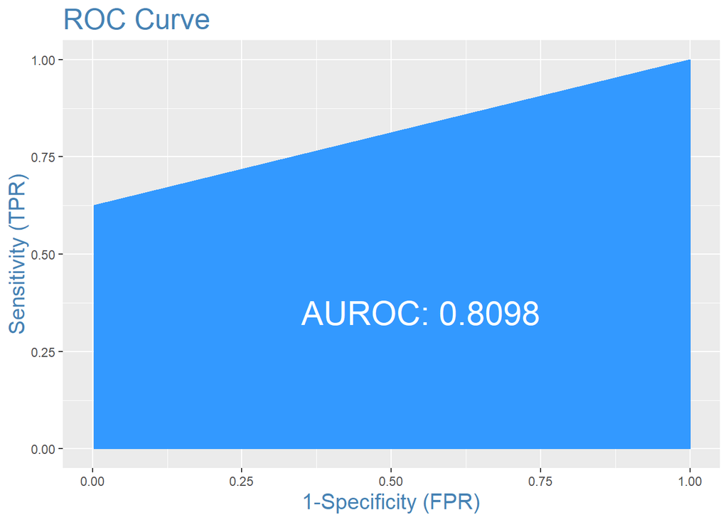

```r
InformationValue::plotROC(holdoutC45$Won,c(as.numeric(predictionsholdRWeka)))
```

# CART Technique with Scaling(Bagging)

```r
#Creating data partition for train,test and Holdout
set.seed(1234)
sampleR <- sample.int(n = nrow(trsfm), size = floor(.65*nrow(trsfm)), replace = F)
sampleR1 <- sample.int(n = nrow(trsfm), size = floor(.15*nrow(trsfm)), replace = F)
sampleR2 <- sample.int(n = nrow(trsfm), size = floor(0.2*nrow(trsfm)), replace = F)

trainRB <- trsfm[sampleR, ]
testRB  <- trsfm[sampleR1,]
holdoutRB <- trsfm[sampleR2,]
# fit model
fitRB <- bagging(Won~., data=trainRB)

# make predictions
predictions <- predict(fitRB,testRB, type="class")
predictionsH <- predict(fitRB,holdoutRB, type="class")
# summarize accuracy


caret::confusionMatrix(predictions,testRB$Won, positive="1", mode="everything")
```

```
## Confusion Matrix and Statistics
##
##           Reference
## Prediction   0   1
##          0 669   0
##          1   4  61
##
##                Accuracy : 0.9946
##                  95% CI : (0.9861, 0.9985)
##     No Information Rate : 0.9169
##     P-Value [Acc > NIR] : <2e-16
##
##                   Kappa : 0.9653
##
##  Mcnemar's Test P-Value : 0.1336
##
##             Sensitivity : 1.00000
##             Specificity : 0.99406
##          Pos Pred Value : 0.93846
##          Neg Pred Value : 1.00000
##               Precision : 0.93846
##                  Recall : 1.00000
##                      F1 : 0.96825
##              Prevalence : 0.08311
##          Detection Rate : 0.08311
##    Detection Prevalence : 0.08856
##       Balanced Accuracy : 0.99703
##
##        'Positive' Class : 1
##
```

```r
caret::confusionMatrix(predictionsH,holdoutRB$Won, positive="1", mode="everything")
```

```
## Confusion Matrix and Statistics
##
##           Reference
## Prediction   0   1
##          0 904   3
##          1   6  66
##
##                Accuracy : 0.9908
##                  95% CI : (0.9826, 0.9958)
##     No Information Rate : 0.9295
##     P-Value [Acc > NIR] : <2e-16
##
##                   Kappa : 0.9312
##
##  Mcnemar's Test P-Value : 0.505
##
##             Sensitivity : 0.95652
##             Specificity : 0.99341
##          Pos Pred Value : 0.91667
##          Neg Pred Value : 0.99669
##               Precision : 0.91667
##                  Recall : 0.95652
##                      F1 : 0.93617
##              Prevalence : 0.07048
##          Detection Rate : 0.06742
##    Detection Prevalence : 0.07354
##       Balanced Accuracy : 0.97496
##
##        'Positive' Class : 1
##
```

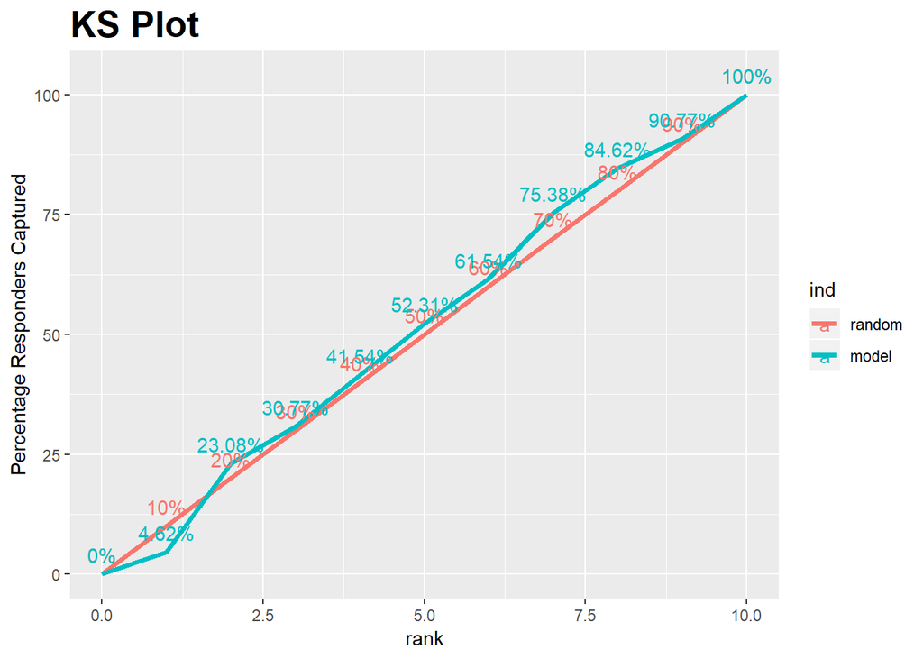

```r
ks_plot(predictions,testRB$Won)
```

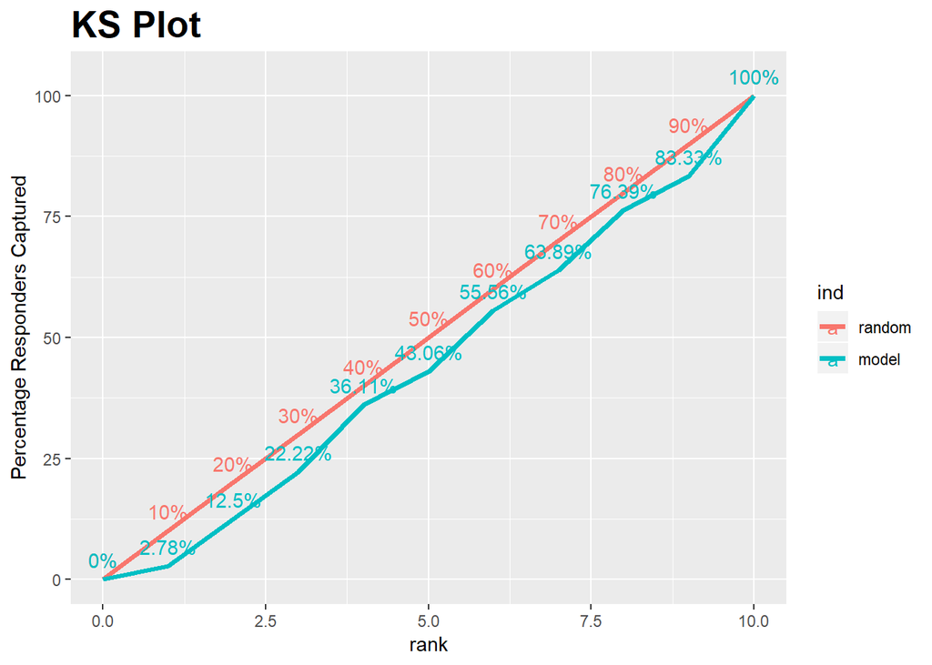

```r
ks_plot(predictionsH,holdoutRB$Won)
```

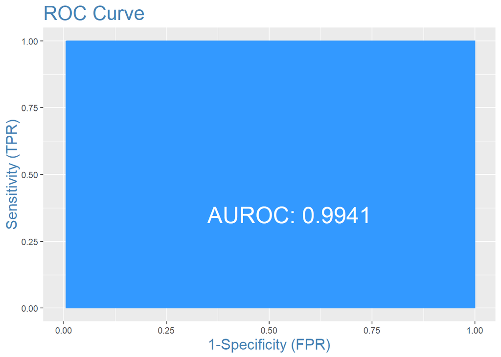

```r
InformationValue::plotROC(testRB$Won,c(as.numeric(predictions)))
```

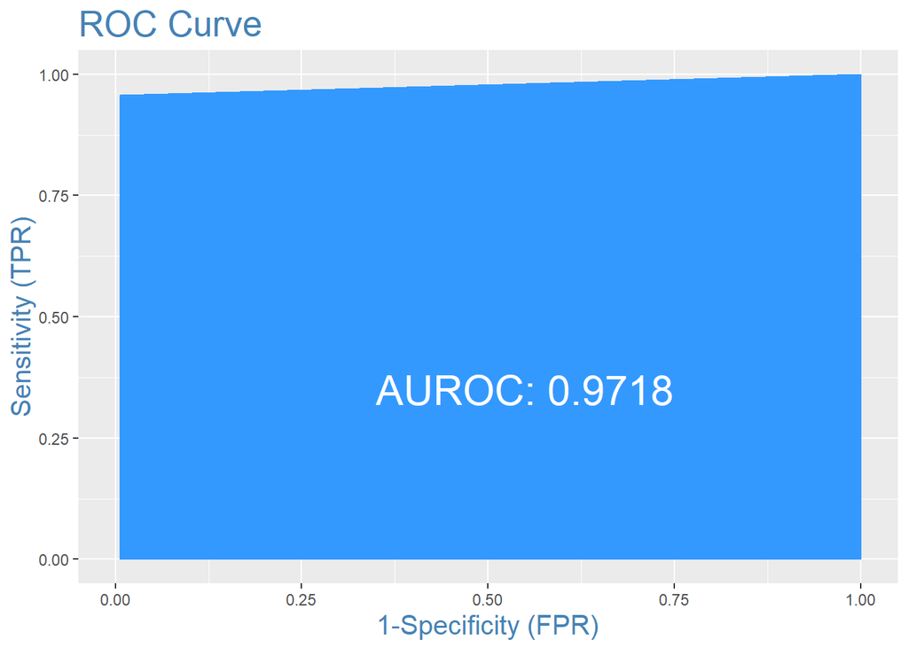

```r
InformationValue::plotROC(holdoutRB$Won,c(as.numeric(predictionsH)))
```

# RandomForest

```r
#Creating data partition for train,test and Holdout
set.seed(134567)
trsfm1<-trsfm[,c(-1,-3,-5)]
sampleR <- sample.int(n = nrow(trsfm1), size = floor(.65*nrow(trsfm1)), replace = F)
sampleR1 <- sample.int(n = nrow(trsfm1), size = floor(.15*nrow(trsfm1)), replace = F)
sampleR2 <- sample.int(n = nrow(trsfm1), size = floor(0.2*nrow(trsfm1)), replace = F)

trainRand <- trsfm1[sampleR, ]
testRand  <- trsfm1[sampleR1,]
holdoutRand <- trsfm1[sampleR2,]

#To avoid Error in eval(predvars,data,env) from running model fitment
names(trainRand) <- make.names(names(trainRand))
names(testRand) <- make.names(names(testRand))
names(holdoutRand) <- make.names(names(holdoutRand))
# fit model
#mtry is SQRT(P) = SQRT(19)=
trainrandomfit <- randomForest(Won~., data=trainRand,
                importance=TRUE,ntree=200,mtry=8)

print(trainrandomfit)
```

```
##
## Call:
##  randomForest(formula = Won ~ ., data = trainRand, importance = TRUE,      ntree = 200, mtry = 8)
##                Type of random forest: classification
##                      Number of trees: 200
## No. of variables tried at each split: 8
##
##         OOB estimate of  error rate: 2.95%
## Confusion matrix:
##      0   1 class.error
## 0 2898  44  0.01495581
## 1   50 191  0.20746888
```

```r
# summarize the fit
summary(trainrandomfit)
```

```
##                 Length Class  Mode
## call               6   -none- call
## type               1   -none- character
## predicted       3183   factor numeric
## err.rate         600   -none- numeric
## confusion          6   -none- numeric
## votes           6366   matrix numeric
## oob.times       3183   -none- numeric
## classes            2   -none- character
## importance        72   -none- numeric
## importanceSD      54   -none- numeric
## localImportance    0   -none- NULL
## proximity          0   -none- NULL
## ntree              1   -none- numeric
## mtry               1   -none- numeric
## forest            14   -none- list
## y               3183   factor numeric
## test               0   -none- NULL
## inbag              0   -none- NULL
## terms              3   terms  call
```

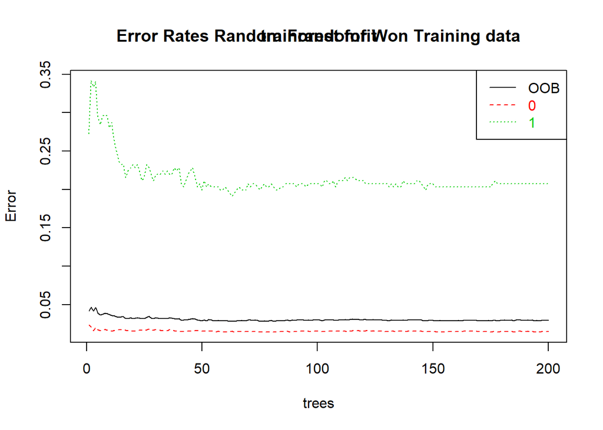

```r
#Plot to to check for optimal number of Tree value
plot(trainrandomfit)
legend("topright", c("OOB", "0", "1"), text.col=1:6, lty=1:3, col=1:3)
title(main="Error Rates Random Forest for Won Training data")
```

```r
impVar <- round(randomForest::importance(trainrandomfit), 2)

impVar[order(impVar[,1], decreasing=TRUE),]
```

```
##                                     0      1 MeanDecreaseAccuracy
## TOTALVALIDVOTESPOLLED           92.00 139.65               127.84
## AC_NO                            4.84   3.88                 6.15
## netasset                         4.60  -4.32                 0.26
## CAND_AGE                         2.08  -0.73                 0.85
## Criminal.Case                    1.77  -5.71                -2.56
## Education_Ignored                1.52  -0.08                 1.34
## CAND_CATEGORY_SC                 0.74  -0.41                 0.59
## Education_Literate               0.53   8.32                 7.93
## CAND_SEX_M                       0.21   0.63                 0.57
## Education_Post.Graduate          0.11   0.39                 0.17
## Education_Illiterate             0.00   0.00                 0.00
## Education_Under.Graduate        -0.17   2.86                 2.12
## CAND_CATEGORY_GEN               -0.20  -0.95                -0.97
## Education_Graduate              -0.48   1.47                 0.79
## CAND_CATEGORY_ST                -1.00  -1.00                -1.42
## Education_Doctorate             -1.24   2.86                 0.90
## CAND_SEX_F                      -1.40   0.02                -0.80
## Education_Graduate.Professional -2.70  -1.92                -3.09
##                                 MeanDecreaseGini
## TOTALVALIDVOTESPOLLED                     329.59
## AC_NO                                      30.64
## netasset                                   25.16
## CAND_AGE                                   24.40
## Criminal.Case                               8.42
## Education_Ignored                           1.68
## CAND_CATEGORY_SC                            1.65
## Education_Literate                          1.77
## CAND_SEX_M                                  1.22
## Education_Post.Graduate                     3.03
## Education_Illiterate                        0.00
## Education_Under.Graduate                    2.59
## CAND_CATEGORY_GEN                           1.82
## Education_Graduate                          1.87
## CAND_CATEGORY_ST                            0.12
## Education_Doctorate                         2.14
## CAND_SEX_F                                  1.49
## Education_Graduate.Professional             1.43
```